# Big Mart Sales Data

**Dataset Overview**

BigMart have collected 2013 sales data for 1559 products across 10 stores in different cities. Also, certain attributes of each product and store have been defined.

The data has been collected form the following link: https://datahack.analyticsvidhya.com/contest/practice-problem-big-mart-sales-iii/

# Data Analysis and Visualizations

It is divided into 3 sections

1. Tiers
2. Outlets
3. Items

```python
base_color = sns.color_palette()[0]
sns.set(rc={'figure.figsize':(8, 6)})
```

## Tiers

### How many outlets are available in each Tier ?

Are the outlets evenly distributed or any specific tier has dominancy in outlets count

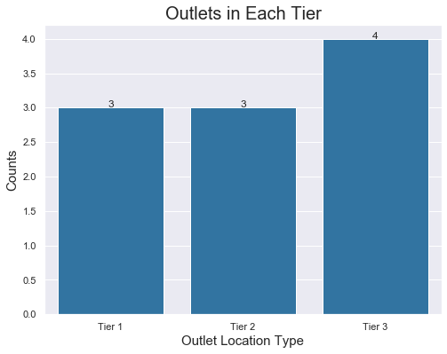

```python
# Creating DF
outlets_in_tier = sales_df.drop_duplicates('outlet_identifier')
outlets_in_tier = outlets_in_tier.groupby('outlet_location_type').count().reset_index()[['outlet_location_type', 'item_identifier']]
outlets_in_tier.columns = ['tier', 'outlet_counts']

# Plotting data
ax = sns.barplot(data = outlets_in_tier, x = 'tier', y='outlet_counts', color=base_color)
ax = setLabels(ax, 'Outlet Location Type', 'Counts', 15, 15)
ax = countplotDataLabels(ax)
ax.set_title('Outlets in Each Tier', fontsize=20);
```

**Observations**

Tier 1 and 2 have 3 outlets in each whereas Tier 3 have 4 outlets

### What is average item counts in each Tier ?

Finding average item count to find even results and remove the advantage of extra outlet in Tier 3.

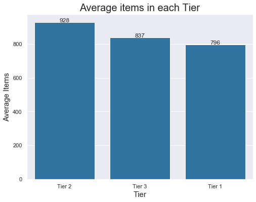

```python
# ordering the data in descending
order = items_per_tier.sort_values('avg_items', ascending=False)['tier']

ax = sns.barplot(data=items_per_tier,
                 x='tier',
                 y='avg_items',
                 color=base_color,
                 order=order);

# adding data labels
ax = countplotDataLabels(ax)
ax = setLabels(ax, 'Tier', 'Average Items', 15, 15)
ax.set_title('Average items in each Tier', fontsize=20);
```

**Observations**:

- Tier 2 has the highest average items.
- Although Tier 3 had an extra outlet, it stands 2nd in average item counts

### Does Tier 2 also have highest sales ?

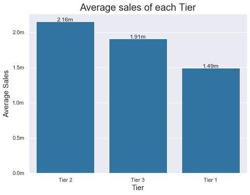

```python
# order = total_sales_per_tier.sort_values('avg_sales', ascending=False).set_index('outlet_location_type').index
order = total_sales_per_tier.sort_values('avg_sales', ascending=False)['tier']

ax = sns.barplot(data=total_sales_per_tier,
                 x='tier',
                 y='avg_sales', order=order, color=base_color)

ax = countplotDataLabels(ax, scale='m', keep_decimals=2, keep_y_decimals = 2)

ax = setLabels(ax, 'Tier', 'Average Sales', 15, 15)
ax.set_title('Average sales of each Tier', fontsize = 20);
```

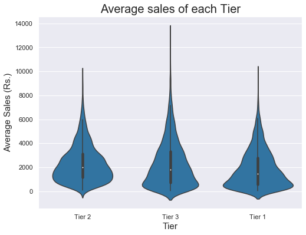

```python
ax = sns.violinplot(data=sales_df,
               x='outlet_location_type',
               y='item_outlet_sales',
               color=base_color, order=order);

ax = setLabels(ax, 'Tier', 'Average Sales (Rs.)', 15, 15)
ax.set_title('Average sales of each Tier', fontsize = 20);
```

**Observations**

1. As Tier 2 have the most items, they also have highest average sales.
2. In violin plot, we can see that Tier 3 almost touched sales of 14000 USD whereas Tier 1 and Tier 2 were below 11000 USD

### Does Tier 2 has maximum number of Large outlet size ?

The reason for Tier for having highest sales may be that they have more large outlets.

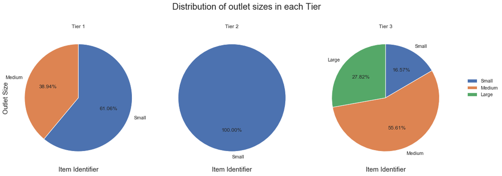

```python
data = outlet_size_count.drop(outlet_size_count[outlet_size_count.item_identifier == 0].index)
g = sns.FacetGrid(data, col="outlet_location_type", height=5)

def pie(values, labels, color=None):
    plt.pie(values, labels=labels.values, autopct='%1.2f%%', counterclock=False, startangle=90)
g = (g.map(pie, 'item_identifier', 'outlet_size').add_legend())

g.set_xlabels('Item Identifier', fontsize = 15)
g.set_ylabels('Outlet Size', fontsize = 15)
g.set_titles('{col_name}', fontsize = 15)
g.fig.suptitle('Distribution of outlet sizes in each Tier', y = 1.1, fontsize = 20);
```

**Observations**:

- Tier 2 only had Small sized outlets yet they were able to generate highest average sales than other tier outlets
- Tier 1 have only Small and Medium sized outlets
- Tier 3 have all types of outlets
- Large outlets are available only in Tier 3

### Are Tier 2 outlets located in of Supermarket Type 1 ?

Now that Tier 2 only have Small sized outlets, maybe they are located in Supermarket Type 1

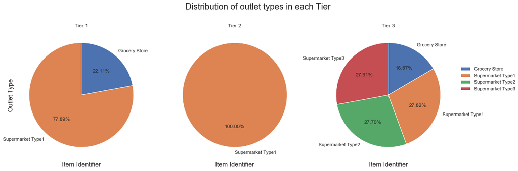

```python
data = outlet_type_count.drop(outlet_type_count[outlet_type_count.item_identifier == 0].index)
g = sns.FacetGrid(data, col="outlet_location_type", height=5)

def pie(values, labels, color=None):
    colours = {'Grocery Store': 'C0',
           'Supermarket Type1': 'C1',
           'Supermarket Type2': 'C2',
           'Supermarket Type3': 'C3'}
    plt.pie(values, labels=labels.values, autopct='%1.2f%%', colors=[colours[key] for key in labels], counterclock=False, startangle=90)
g = (g.map(pie, 'item_identifier', 'outlet_type').add_legend(bbox_to_anchor = (1, 0.6)))

g.set_xlabels('Item Identifier', fontsize = 15)
g.set_ylabels('Outlet Type', fontsize = 15)
g.set_titles('{col_name}', fontsize = 15)
g.fig.suptitle('Distribution of outlet types in each Tier', y = 1.1, fontsize = 20);
```

**Observations**

# Outlets

## Which outlet has generated maximum sales in 2013 ?

### Sales of each outlet by outlet type

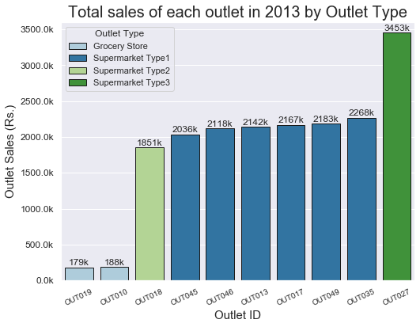

```python
# Creating bar plot
ax = sns.barplot(data=outlets_info_df,
                 x='outlet_identifier', y='item_outlet_sales',
                 hue = 'outlet_type', dodge = False,
                 palette='Paired',
                 edgecolor=".1", linewidth=1,
                 order=outlets_info_df.sort_values('item_outlet_sales')['outlet_identifier'])

ax = countplotDataLabels(ax, scale='k', adjust_label_h=30000)

# setting x and y axis labels and title
ax = setLabels(ax, 'Outlet ID', 'Outlet Sales (Rs.)', 15, 15)
ax.set_title('Total sales of each outlet in 2013 by Outlet Type', fontsize = 20)
ax.legend(loc='upper left').set_title('Outlet Type')

# changing size of x and y labels
ax.tick_params(axis="x", labelsize=10)
ax.tick_params(axis="y", labelsize=12)

# increasing ylim so that the data label is inside the figure
plt.ylim(0, 3600000)

plt.xticks(rotation=25)
plt.show()
```

- **Key Findings:**
  - **Supermarket Type 3 > Supermarket Type 1 > Supermarket Type 2 > Grocery Store**
- **Observations**
  - Outlet 19 an 10
    - Both contributed around 1 percent each
    - Both are Grocery Stores
  - Outlet 18
    - The only Supermarket Type 2 type outlet
    - Contributed 10% it overall sales in 2013
  - Outlet 45, 46, 13, 17, 49, 35
    - Had 11-12% contribution
    - All outlets are Supermarket Type 1
  - Outlet 27
    - Had the highest contribution of 18%
    - Is of Supermarket Type 3

## Are Outlet 19 and 10 newly established?

There may be a chance that those outlets are recently established due to which they are not able to generate maximum sales

**TODO:** Add outlet_establishment_year column in outlets_info_df

```python
outlets_info_df['outlet_establishment_year'] = sales_df.drop_duplicates('outlet_identifier').sort_values('outlet_identifier').reset_index()['outlet_establishment_year']
outlets_info_df['years_since_establishment'] = 2013 + 1 - outlets_info_df['outlet_establishment_year']
outlets_info_df
```

|  | outlet_identifier | item_outlet_sales | outlet_size | outlet_location_type | outlet_type | percent_contrib | total_items_sold | outlet_establishment_year | years_since_establishment |
| --- | --- | --- | --- | --- | --- | --- | --- | --- | --- |
| 0 | OUT010 | 1.883402e+05 | Small | Tier 3 | Grocery Store | 1.013065 | 1323 | 1998 | 16 |
| 1 | OUT013 | 2.142664e+06 | Large | Tier 3 | Supermarket Type1 | 11.525196 | 14910 | 1987 | 27 |
| 2 | OUT017 | 2.167465e+06 | Small | Tier 2 | Supermarket Type1 | 11.658602 | 15427 | 2007 | 7 |
| 3 | OUT018 | 1.851823e+06 | Medium | Tier 3 | Supermarket Type2 | 9.960789 | 12859 | 2009 | 5 |
| 4 | OUT019 | 1.796941e+05 | Small | Tier 1 | Grocery Store | 0.966558 | 1292 | 1985 | 29 |
| 5 | OUT027 | 3.453926e+06 | Medium | Tier 3 | Supermarket Type3 | 18.578359 | 24883 | 1985 | 29 |
| 6 | OUT035 | 2.268123e+06 | Small | Tier 2 | Supermarket Type1 | 12.200030 | 15779 | 2004 | 10 |
| 7 | OUT045 | 2.036725e+06 | Small | Tier 2 | Supermarket Type1 | 10.955364 | 14467 | 2002 | 12 |
| 8 | OUT046 | 2.118395e+06 | Small | Tier 1 | Supermarket Type1 | 11.394658 | 15054 | 1997 | 17 |
| 9 | OUT049 | 2.183970e+06 | Medium | Tier 1 | Supermarket Type1 | 11.747378 | 15472 | 1999 | 15 |

**Observations**

**Interesting finding:** Outlet 19 and 27 are the oldest outlets. They are operating since 29 years. However, Outlet 19 generated least sales and Outlet 27 generated maximum sales

- Outlet 10 is 16 years old.

## What food types are sold per outlet ?

Finding out whether any outlet focuses on particular type of item or not

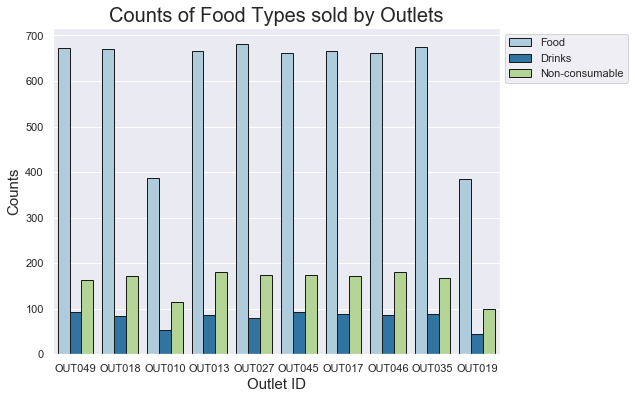

```python
ax = sns.countplot(data=sales_df, x='outlet_identifier', hue='food_type', palette='Paired', edgecolor='0.1')
ax.legend(loc='upper right', bbox_to_anchor=(1.3, 1))
ax = setLabels(ax, 'Outlet ID', 'Counts', 15, 15)
ax.set_title('Counts of Food Types sold by Outlets', fontsize = 20);
```

**Observations**

Type of items sold by outlets: Food > Non-Consumable > Drinks

# Items

## Is there any notable difference in item weight, item mrp and item visibility ?

**Item Weight**

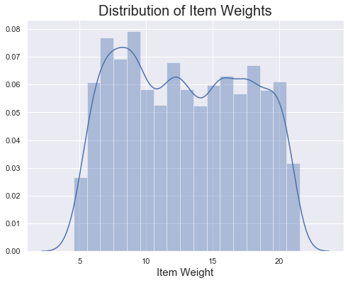

```python
ax = sns.distplot(sales_df.item_weight, bins=np.arange(sales_df.item_weight.min(), sales_df.item_weight.max() + 1, 1));
ax.set_xlabel('Item Weight', fontsize = 15)
ax.set_title('Distribution of Item Weights', fontsize = 20);
```

**Observations**

1. Apart from the lowest and the higest weight, most of the weights have distribution between 0.05 to 0.07

**Item visibility**

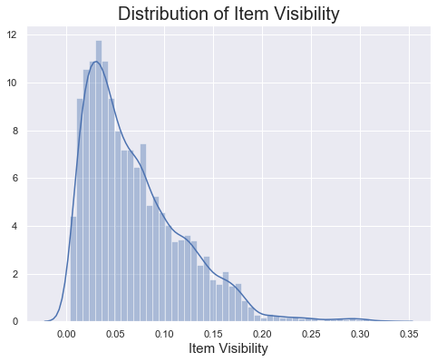

```python
bins = np.arange(0, sales_df.item_visibility.max() + 0.05, 0.05)
ax = sns.distplot(a=sales_df.item_visibility)
ax.set_xlabel('Item Visibility', fontsize = 15)
ax.set_title('Distribution of Item Visibility', fontsize = 20);
```

**Observations**

1. Most of the items have visibility between 0.02 to 0.05
2. Vew few items have visibility of more than 0.20

**Item MRP**

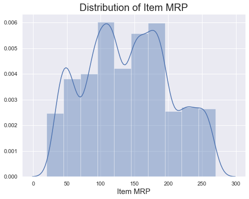

```python
bins = np.arange(20, sales_df.item_mrp.max() + 25, 25)
ax = sns.distplot(sales_df.item_mrp, bins=bins);

ax.set_xlabel('Item MRP', fontsize = 15)
ax.set_title('Distribution of Item MRP', fontsize = 20);
```

**Observation**

- Most of the items are within the rnge of 50 to 200
- The proportion of items above 200 MRP is equal.

## How many food types are available in all the outlets ?

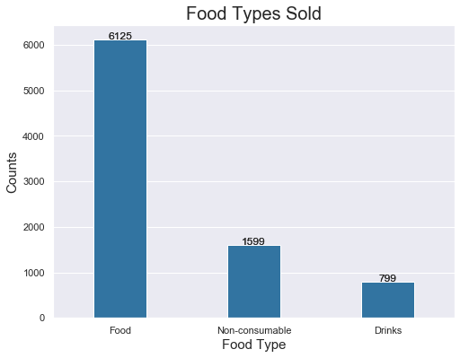

```python
plt.figure(figsize=(8, 6))
ax = sns.countplot(data=sales_df, x='food_type', color=base_color, order=sales_df.food_type.value_counts().index)
ax = countplotDataLabels(ax)
ax = setLabels(ax, 'Food Type', 'Counts', 15, 15)
ax.set_title('Food Types Sold', fontsize = 20)
ax = changeBarWidth(ax, 0.4)
```

**Observations**

1. Food products are sold the most whereas drinks are sold the least.

## Relation between items mrp and item visibility

Finding if items with higher visibility have higher price or not.

**General comparison**

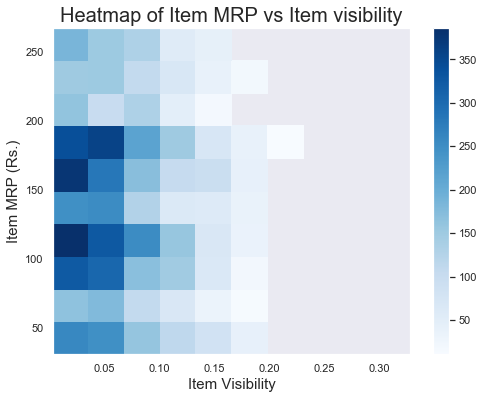

```python
plt.hist2d(data=sales_df, x = 'item_visibility', y = 'item_mrp', cmap='Blues', cmin=10);
plt.colorbar();
plt.title('Heatmap of Item MRP vs Item visibility', fontsize = 20);
plt.xlabel('Item Visibility', fontsize = 15);
plt.ylabel('Item MRP (Rs.)', fontsize = 15);
```

**Observation**

1. Most of the items with visibility between 0.00 to 0.10 have mrp range of 100 to 200
2. When we keep limit minimum of 10 items in each heatmap block, we can see that there are hardly any items with more than 0.20 visibility.

**Comparison by Tier and Outlet type**

Having a deeper look in the item MRP and visiblity relations using FacetGrid to view relations in each Tier and Outlet Type

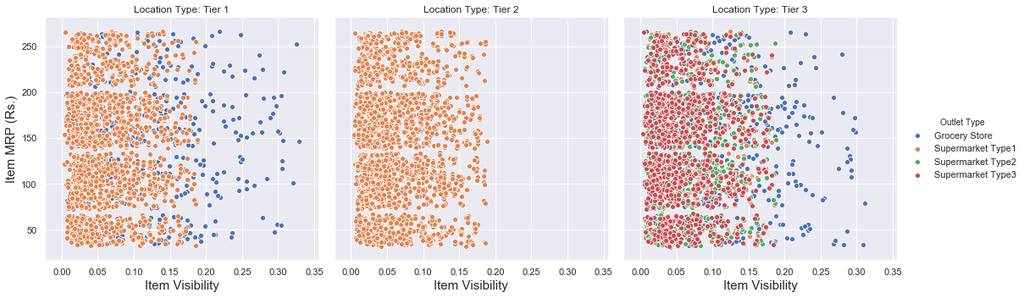

```python
g = sns.FacetGrid(data=sales_df,
                  col='outlet_location_type',
                  hue='outlet_type',
                  height=5)
g.map(sns.scatterplot, 'item_visibility', 'item_mrp')
g.add_legend(title='Outlet Type')

g.set_titles(col_template='Location Type: {col_name}', fontsize=20)

g.set_xlabels('Item Visibility', fontsize = 15)
g.set_ylabels('Item MRP (Rs.)', fontsize = 15);
```

**Observations**

1. Supermarkets have item visibility range from 0.00 to 0.20. None of the products cross 0.20.
2. Only Grocery Stores have item visibility range from 0.00 to 0.33. They are the only outlets which have item visibility above 0.20 to 0.33.

## Relation between total item sold and total sales

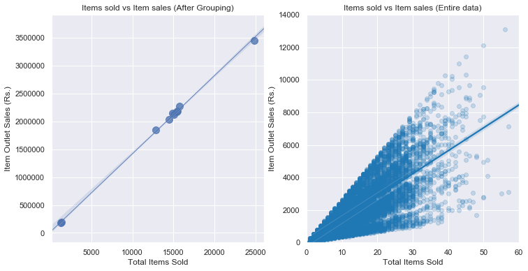

```python
fig, axes = plt.subplots(1,2, figsize=(12, 6))

ax1 = sns.regplot(data=outlets_info_df,
            x='total_items_sold', y='item_outlet_sales',
            scatter_kws={"s": 100}, line_kws={'linewidth' : .8}, ax=axes[0])


ax2 = sns.regplot(data=sales_df, y='item_outlet_sales', x='total_items_sold', scatter_kws={'alpha':.2}, ax=axes[1], color=base_color)
ax2.set_xlim(0, 60);
ax2.set_ylim(0, 14000);

ax1 = setLabels(ax1, 'Total Items Sold', 'Item Outlet Sales (Rs.)');
ax1.set_title('Items sold vs Item sales (After Grouping)');

ax2 = setLabels(ax2, 'Total Items Sold', 'Item Outlet Sales (Rs.)');
ax2.set_title('Items sold vs Item sales (Entire data)');
```

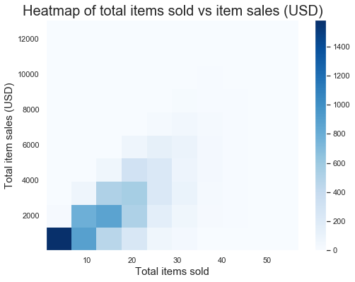

```python
plt.hist2d(data=sales_df, x = 'total_items_sold', y = 'item_outlet_sales', cmap='Blues')
plt.xlabel('Total items sold', fontsize = 15)
plt.ylabel('Total item sales (USD)', fontsize = 15)
plt.title('Heatmap of total items sold vs item sales (USD)', fontsize = 20)
plt.colorbar();
```

**Observations**

## Relation between Item MRP and Item Outlet Sales

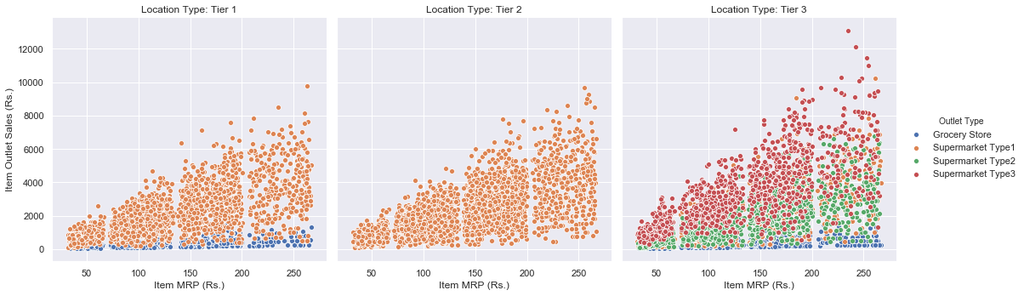

```python
g = sns.FacetGrid(data=sales_df, col='outlet_location_type', hue='outlet_type', height=5)
g.map(sns.scatterplot, 'item_mrp', 'item_outlet_sales')
g.add_legend(title='Outlet Type')

g.set_titles(col_template='Location Type: {col_name}')

g.set_xlabels('Item MRP (Rs.)')
g.set_ylabels('Item Outlet Sales (Rs.)');
```

**Observations**

1. Outlets types by their threhold in sales in descending order:
   - Supermarket Type 3 > Supermarket Type 1 > Supermarket Type 2 > Grocery Store

## Which type of items are sold the most

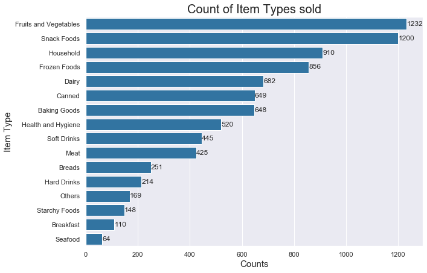

```python
plt.figure(figsize=(10, 7))
ax = sns.countplot(data=sales_df, y='item_type', order=sales_df.item_type.value_counts().index, color=base_color)
ax = countplotDataLabels(ax, orient='h')
ax = setLabels(ax, 'Counts', 'Item Type', 15, 15)
ax.set_title('Count of Item Types sold', fontsize = 20);
```

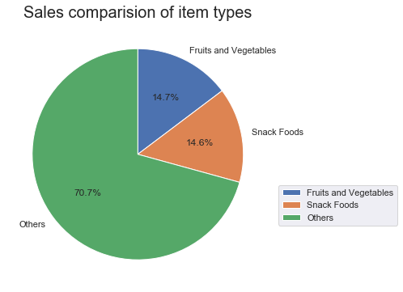

```python
plt.pie(outlets_top_sales.total_contribution, labels=outlets_top_sales.item_type, autopct='%1.1f%%', counterclock=False, startangle=90);
plt.title('Sales comparision of item types', fontsize = 20)
plt.legend(outlets_top_sales.item_type, bbox_to_anchor=(1.5, 0.4));
```

**Observations**

1. Fruits and Vegetables are the most sold items (1232) followed by Snack Foods (1200).
2. Dairy items sold were half to Fruits and Vegetables (682)
3. 29% sales is generated by Fruits and Vegetables and Snack Foods. Having them in a new store is a good idea to invest.

# Conclusion